# Within-person event-study & difference-in-differences with **vivainsights** in R

2026-11-17

# Measuring behaviour change with an event-study / difference-in-differences

## Introduction

A common question in Copilot Analytics is *causal*: **did a person’s collaboration behaviour change after they started using Copilot**, or are heavy users simply different people to begin with? A plain comparison of users vs non-users cannot separate the two, because adoption is not random.

A **within-person event-study** paired with a **difference-in-differences (DiD)** design is a standard way to approach this. The design:

- aligns every adopter on their own **event time** (weeks relative to the week they adopted Copilot),
- compares adopters against a control group of non-adopters over the same calendar weeks,
- absorbs each person’s baseline (**person fixed effects**) and every calendar week’s common shocks within each organisational function (**function-by-week fixed effects**), and
- reads the estimate as the *within-person* change in the treated group relative to the control group.

Adoption here is **staggered**: people adopt in different weeks. A single two-way fixed-effects (TWFE) regression can give misleading estimates in that setting when effects differ by adoption cohort or change over time, because already-adopted people can end up acting as comparisons for later adopters (Goodman-Bacon 2021; de Chaisemartin and D’Haultfoeuille 2020). This notebook therefore uses the **Sun and Abraham (2021) interaction-weighted estimator** as the primary estimate. It estimates an effect for each adoption cohort and event week, using never-adopters as the comparison group, then averages those effects. The naive TWFE event study is kept only as a comparison.

The results are estimates under assumptions (chiefly parallel trends and no anticipation), and are best read as associations consistent with an effect rather than proof of one.

Person Query exports do not ship with a clean adoption event, so this notebook builds a **small seeded simulation** whose column names match a real Person Query. The downstream modelling code therefore runs on a real export loaded with `vivainsights::import_query()`, so you swap out the data-generation chunk and map your outcome columns (shown below). The simulation injects a **clearly-labelled illustrative effect** so the model has something to recover; this is for demonstration only and is not a real result.

## Set-up

This example uses **fixest** (a recent version, tested with 0.14.2) for fast fixed-effects estimation; install it with `install.packages("fixest")` if you do not already have it.

```r
knitr::opts_chunk$set(warning = FALSE, message = FALSE)
library(dplyr)
library(tidyr)
library(ggplot2)
library(scales)
library(fixest)   # fast fixed-effects estimation (feols, sunab(), i())
```

To run this notebook on your **own** export instead of the simulation, replace the simulation chunk below with the following, then continue unchanged from the *“Derive the adoption week”* section:

```r
panel <- vivainsights::import_query("your-person-query.csv")
app_cols <- grep("^Copilot_actions_taken_in", names(panel), value = TRUE)
panel <- panel %>%
  mutate(across(all_of(app_cols), ~ tidyr::replace_na(.x, 0))) %>%
  mutate(Total_Copilot_actions_taken = rowSums(across(all_of(app_cols))))
# map your HR function attribute (for example FunctionType or Organization) to
# Function. Use a value measured before adoption, so that Copilot use cannot
# have changed it. Freezing each person's first observed value keeps a later
# move between functions out of the fixed effects.
panel <- panel %>%
  group_by(PersonId) %>%
  mutate(Function = dplyr::first(FunctionType, order_by = MetricDate)) %>%
  ungroup()
# choose the outcome column(s) to model, e.g. Collaboration_hours, Chat_hours,
# Emails_sent -- these are standard Person Query columns.
```

## Simulate a Person-Query-shaped panel

The block below creates a weekly panel with the same shape as a Person Query: one row per `PersonId` x `MetricDate`, a synthetic organisational `Function` column, a `Total_Copilot_actions_taken` column, and a few collaboration outcomes (`Collaboration_hours`, `Chat_hours`, `Emails_sent`). Treated people adopt Copilot at a **staggered** week; control people never adopt. Rollout follows function (each function has its own adoption window and its own collaboration trend), but adoption weeks still vary within each function. We also add person baselines, calendar-week seasonality, and noise so the panel looks realistic.

> **Replace this chunk for real data.** Load your export with `vivainsights::import_query()` and derive the adoption week from the first week of non-zero Copilot actions (see the next section). Everything downstream stays the same.

```r
set.seed(100)

n_persons <- 400L
n_weeks   <- 40L
weeks     <- seq(as.Date("2024-01-01"), by = "week", length.out = n_weeks)

# ---- clearly-labelled illustrative effect ---------------------------------
# DEMO ONLY: this is the size of the behaviour change we inject into treated
# people after adoption. Set to 0 (or delete) when running on real data, so the
# model should estimate the effect, not have it baked in.
TREATMENT_EFFECT <- 0.8   # extra collaboration hours/week once adopted
# ---------------------------------------------------------------------------

# Synthetic organisational function. Rollout follows function: earlier-rolled-out
# functions also have rising collaboration trends. Values are illustrative.
FUNCTIONS      <- c("Sales", "Engineering", "Operations", "Finance")
P_ADOPT        <- c(Sales = 0.8, Engineering = 0.6, Operations = 0.5, Finance = 0.4)
ROLLOUT_START  <- c(Sales = 10L, Engineering = 12L, Operations = 16L, Finance = 18L)
FUNCTION_TREND <- c(Sales = 0.04, Engineering = 0, Operations = -0.02, Finance = -0.04)

persons <- tibble(
  PersonId    = sprintf("P%04d", seq_len(n_persons)),
  # synthetic organisational function: rollout follows function, so function
  # confounds adoption (see the Function section below)
  Function    = sample(FUNCTIONS, n_persons, replace = TRUE)
) %>%
  mutate(
    treated     = rbinom(n_persons, 1, P_ADOPT[Function]),
    # person baseline (some people simply collaborate more than others)
    base_collab = rnorm(n_persons, mean = 12, sd = 3)
  )

# Treated people adopt at a staggered week. Each function has its own rollout
# window, but adoption weeks still vary within function. Controls never adopt.
persons <- persons %>%
  mutate(adopt_week = ifelse(
    treated == 1,
    ROLLOUT_START[Function] + sample(0:10, n_persons, replace = TRUE),
    NA_integer_
  ))

# calendar-week seasonality shared by everyone
week_shock <- tibble(
  week_idx  = seq_len(n_weeks),
  MetricDate = weeks,
  season    = 1.5 * sin(2 * pi * seq_len(n_weeks) / 26)
)

# function-specific week shocks: a linear trend plus random weekly noise
function_shock <- tidyr::crossing(Function = FUNCTIONS, week_idx = seq_len(n_weeks)) %>%
  mutate(function_shock = FUNCTION_TREND[Function] * week_idx +
           rnorm(n(), 0, 0.5))

panel <- tidyr::crossing(PersonId = persons$PersonId, week_idx = seq_len(n_weeks)) %>%
  left_join(persons, by = "PersonId") %>%
  left_join(week_shock, by = "week_idx") %>%
  left_join(function_shock, by = c("Function", "week_idx")) %>%
  mutate(
    adopted_now = treated == 1 & week_idx >= adopt_week,
    # Copilot actions: 0 before adoption, positive afterwards (treated only)
    Total_Copilot_actions_taken = ifelse(
      adopted_now, rpois(n(), lambda = 25), 0L
    ),
    # primary outcome: baseline + season + function shock + injected effect
    # (post-adoption) + noise
    Collaboration_hours = base_collab + season + function_shock +
      ifelse(adopted_now, TREATMENT_EFFECT, 0) +
      rnorm(n(), 0, 2),
    # two correlated collaboration outcomes for the composite index later
    Chat_hours  = 0.35 * Collaboration_hours + rnorm(n(), 0, 0.8),
    Emails_sent = 20 + 1.2 * Collaboration_hours + rnorm(n(), 0, 4)
  ) %>%
  select(PersonId, Function, MetricDate, week_idx, treated,
         Total_Copilot_actions_taken,
         Collaboration_hours, Chat_hours, Emails_sent)

head(panel)
```

```
## # A tibble: 6 × 9
##   PersonId Function    MetricDate week_idx treated Total_Copilot_actions_taken
##   <chr>    <chr>       <date>        <int>   <int>                       <int>
## 1 P0001    Engineering 2024-01-01        1       1                           0
## 2 P0001    Engineering 2024-01-08        2       1                           0
## 3 P0001    Engineering 2024-01-15        3       1                           0
## 4 P0001    Engineering 2024-01-22        4       1                           0
## 5 P0001    Engineering 2024-01-29        5       1                           0
## 6 P0001    Engineering 2024-02-05        6       1                           0
## # ℹ 3 more variables: Collaboration_hours <dbl>, Chat_hours <dbl>,
## #   Emails_sent <dbl>
```

## Derive the adoption week and event time

On a real export you would not know who is “treated”; you would infer it from the data. Here we reproduce that realistic step: a person is an **adopter** if they ever record a non-zero Copilot action, and their **adoption week** is the first such week. Control people (never any actions) are assigned a **placebo** adoption week (the median adopter week), so they contribute a comparable event-time window.

```r
adopt <- panel %>%
  filter(Total_Copilot_actions_taken > 0) %>%
  group_by(PersonId) %>%
  summarise(adopt_date = min(MetricDate), .groups = "drop")

# Calendar-week number and adoption cohort for the staggered-robust estimator.
# Never-adopters are coded 1000, a value outside the observed period range, which
# is how fixest::sunab() identifies the never-treated cohort.
NEVER <- 1000L
first_date <- min(panel$MetricDate)
panel <- panel %>%
  left_join(adopt, by = "PersonId") %>%
  mutate(
    is_adopter = !is.na(adopt_date),
    week_num   = as.integer((MetricDate - first_date) / 7) + 1L,
    cohort     = ifelse(is_adopter,
                        as.integer((adopt_date - first_date) / 7) + 1L,
                        NEVER)
  )

# Early adopters with no observed pre-period cannot contribute to an adoption
# estimate: they look like people treated for the whole window, so there is no
# "before" to compare with (see the "check pre-adoption" section of
# https://microsoft.github.io/viva-insights-sample-code/articles/causal-questions-ai-usage/#check-pre-adoption ).
# Drop people with fewer than MIN_PRE observed pre-adoption weeks.
MIN_PRE <- 4L
early <- panel %>%
  filter(is_adopter) %>%
  group_by(PersonId) %>%
  summarise(n_pre = sum(week_num < cohort), .groups = "drop") %>%
  filter(n_pre < MIN_PRE)
cat(sprintf(
  "Dropped %d people who adopted with fewer than %d observed pre-adoption weeks (no usable 'before').\n",
  nrow(early), MIN_PRE
))
```

```
## Dropped 0 people who adopted with fewer than 4 observed pre-adoption weeks (no usable 'before').
```

```r
panel <- panel %>% filter(!PersonId %in% early$PersonId)

adopt <- filter(adopt, !PersonId %in% early$PersonId)
placebo_date <- as.Date(median(adopt$adopt_date))

panel <- panel %>%
  mutate(
    anchor     = dplyr::coalesce(adopt_date, placebo_date),
    event_week = as.integer((MetricDate - anchor) / 7)
  )

# Keep a balanced +/- 8-week window around each person's anchor
# (used for the naive TWFE comparison only)
WINDOW <- 8L
panel_es <- panel %>%
  filter(event_week >= -WINDOW, event_week <= WINDOW) %>%
  group_by(PersonId) %>%
  filter(sum(event_week < 0) >= 4, sum(event_week > 0) >= 4) %>%
  ungroup() %>%
  mutate(
    treated_grp = as.integer(is_adopter),
    post        = as.integer(event_week >= 0),
    treat_post  = post * treated_grp
  )

panel_es %>%
  distinct(PersonId, treated_grp) %>%
  count(group = ifelse(treated_grp == 1, "Adopter (treated)", "Non-adopter (control)"))
```

```
## # A tibble: 2 × 2
##   group                     n
##   <chr>                 <int>
## 1 Adopter (treated)       230
## 2 Non-adopter (control)   170
```

## Primary estimate: Sun and Abraham interaction-weighted event study

The estimator fits a coefficient for every adoption cohort $g$ and calendar week, relative to the week before adoption (event time -1), with never-adopters as the comparison group:

$$y_{it} = \alpha_i + \gamma_{f(i)t} +
\sum_{g}\sum_{\ell \ne -1} \delta_{g,\ell}\,\mathbf{1}\{G_i =
g\}\,\mathbf{1}\{t - g = \ell\} + \varepsilon_{it}$$

where $\alpha_i$ are person fixed effects, $\gamma_{f(i)t}$ are **function-by-calendar-week fixed effects**, and standard errors are clustered by person. The cohort-specific coefficients are then averaged, weighted by cohort share, to give one effect per event week. In `fixest` this is the `sunab(cohort, period)` term. It uses the full panel, because the estimator compares each cohort with never-adopters in calendar time and needs no placebo adoption week.

### Why function-by-week effects

In many organisations Copilot rollout follows function, and functions can have their own collaboration trends. If so, a plain week fixed effect compares an early-rollout function with never-adopters in other functions that were on a different path. Function-by-week fixed effects (`Function^week_num` in `fixest`) compare adopters with never-adopters in the same function and the same calendar week, which is the function-confounding point in the [causal decision guide](https://microsoft.github.io/viva-insights-sample-code/articles/causal-questions-ai-usage/#function-confounding). This conditions on function as measured, so it addresses function-level differences and nothing else. The chunk after the primary fit shows the same model with week fixed effects only, for comparison.

```r
es_sa <- fixest::feols(
  Collaboration_hours ~ sunab(cohort, week_num, ref.p = -1) |
    PersonId + Function^week_num,
  data    = panel,
  cluster = ~PersonId
)

# Average treatment effect on the treated (ATT), averaged over post-adoption weeks
summary(es_sa, agg = "ATT")
```

```
## OLS estimation, Dep. Var.: Collaboration_hours
## Observations: 16,000
## Fixed-effects: PersonId: 400,  Function^week_num: 160
## Standard-errors: Clustered (PersonId)
##     Estimate Std. Error t value   Pr(>|t|)
## ATT 0.763451   0.149877 5.09386 5.4229e-07 ***
## ---
## Signif. codes:  0 '***' 0.001 '**' 0.01 '*' 0.05 '.' 0.1 ' ' 1
## RMSE: 1.91932     Adj. R2: 0.739279
##                 Within R2: 0.054949
```

```r
att <- coeftable(es_sa, agg = "ATT")
cat(sprintf(
  "\nSun-Abraham ATT estimate (function-by-week FE): %+.2f collaboration hours/week (SE %.2f; injected demo effect was %+.2f)\n",
  att[1, "Estimate"], att[1, "Std. Error"], TREATMENT_EFFECT
))
```

```
##
## Sun-Abraham ATT estimate (function-by-week FE): +0.76 collaboration hours/week (SE 0.15; injected demo effect was +0.80)
```

```r
# Comparison only: week fixed effects without conditioning on function
es_sa_nf <- fixest::feols(
  Collaboration_hours ~ sunab(cohort, week_num, ref.p = -1) | PersonId + week_num,
  data    = panel,
  cluster = ~PersonId
)
att_nf <- coeftable(es_sa_nf, agg = "ATT")
cat(sprintf(
  "Same model, week FE only (no function conditioning): ATT %+.2f (SE %.2f)\n",
  att_nf[1, "Estimate"], att_nf[1, "Std. Error"]
))
```

```
## Same model, week FE only (no function conditioning): ATT +0.98 (SE 0.15)
```

The estimate should land close to the injected `TREATMENT_EFFECT`. On real data you would not know the true value, and the estimate depends on the assumptions listed above.

## The event-study: look at pre-trends and see the estimate emerge

A single average hides the **parallel-trends** assumption. The event-study version shows a separate estimate for each event week (relative to week -1). If the design is credible, the **pre-adoption** estimates should sit near zero, and the **post-adoption** estimates should step up to the effect.

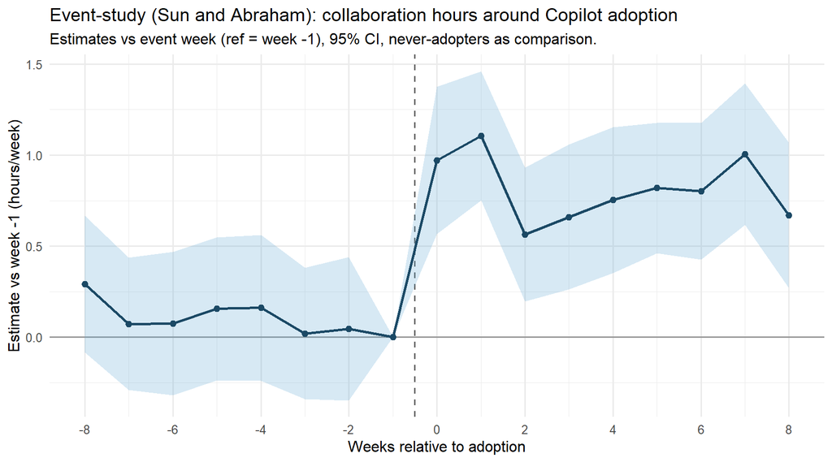

```r
# Event-time estimates aggregated across cohorts (one per relative week)
es_tab <- as.data.frame(coeftable(es_sa))
es_tab$term <- rownames(es_tab)
es_coefs <- es_tab %>%
  filter(grepl("^week_num::", term)) %>%
  mutate(
    event_week = as.integer(sub("^week_num::(-?\\d+).*", "\\1", term)),
    lwr = Estimate - 1.96 * `Std. Error`,
    upr = Estimate + 1.96 * `Std. Error`
  ) %>%
  filter(event_week >= -WINDOW, event_week <= WINDOW)

# Add the reference week (-1) at exactly 0
es_coefs <- bind_rows(
  es_coefs,
  tibble(event_week = -1, Estimate = 0, lwr = 0, upr = 0)
) %>% arrange(event_week)

ggplot(es_coefs, aes(event_week, Estimate)) +
  geom_hline(yintercept = 0, colour = "grey60") +
  geom_vline(xintercept = -0.5, linetype = "dashed", colour = "grey40") +
  geom_ribbon(aes(ymin = lwr, ymax = upr), fill = "#5fa8d3", alpha = 0.25) +
  geom_line(linewidth = 1, colour = "#1b4965") +
  geom_point(size = 2, colour = "#1b4965") +
  scale_x_continuous(breaks = seq(-WINDOW, WINDOW, 2)) +
  labs(
    title    = "Event-study (Sun and Abraham): collaboration hours around Copilot adoption",
    subtitle = "Estimates vs event week (ref = week -1), 95% CI, never-adopters as comparison.",
    x = "Weeks relative to adoption", y = "Estimate vs week -1 (hours/week)"
  ) +
  theme_minimal(base_size = 12)
```

### Pre-trend check

A joint Wald test on the pre-adoption estimates in the plotted window (event weeks -8 to -2, excluding the reference week -1) asks whether they are jointly different from zero. The averaging weights are rebuilt from the cohort-specific coefficients, so the test uses the same person-clustered covariance as the plot.

The primary estimate above conditions on function through function-by-week fixed effects, as described earlier. The pre-trend test in the next chunk is built from the same model, so it conditions on function as well.

```r
b  <- es_sa$coefficients
V  <- vcov(es_sa)
mm <- model.matrix(es_sa)
leads <- -WINDOW:-2

# Weights that average cohort-specific coefficients into one estimate per lead
A <- t(sapply(leads, function(l) {
  w  <- numeric(length(b))
  nm <- grep(sprintf("^week_num::%d:cohort::", l), names(b))
  n_obs <- colSums(sign(mm[, names(b)[nm], drop = FALSE]))
  w[nm] <- n_obs / sum(n_obs)
  w
}))

lead_est <- as.numeric(A %*% b)
wald_chi <- as.numeric(t(lead_est) %*% solve(A %*% V %*% t(A)) %*% lead_est)
cat(sprintf("Joint test of %d pre-adoption leads: chi-squared = %.2f, p = %.3f\n",
            length(leads), wald_chi,
            pchisq(wald_chi, df = length(leads), lower.tail = FALSE)))
```

```
## Joint test of 7 pre-adoption leads: chi-squared = 4.01, p = 0.779
```

A non-significant pre-test does not establish parallel trends. The test can have low power, and it cannot rule out a trend that starts at adoption. Read it together with the plot, and with what you know about why people adopted when they did.

## Comparison: naive TWFE (shown for comparison)

For comparison only, the block below fits the single-coefficient TWFE DiD and the TWFE event study that many analyses start with. With staggered adoption and possibly different effects by cohort, these can be contaminated, so treat them as a sensitivity check against the Sun and Abraham estimate above, not as the headline. They use the +/- 8-week window around each person’s anchor, with a placebo anchor for controls.

```r
did <- fixest::feols(
  Collaboration_hours ~ treat_post | PersonId + MetricDate,
  data    = panel_es,
  cluster = ~PersonId
)

summary(did)
```

```
## OLS estimation, Dep. Var.: Collaboration_hours
## Observations: 6,799
## Fixed-effects: PersonId: 400,  MetricDate: 34
## Standard-errors: Clustered (PersonId)
##            Estimate Std. Error t value  Pr(>|t|)
## treat_post 0.844994   0.099107 8.52612 3.164e-16 ***
## ---
## Signif. codes:  0 '***' 0.001 '**' 0.01 '*' 0.05 '.' 0.1 ' ' 1
## RMSE: 1.96742     Adj. R2: 0.718907
##                 Within R2: 0.012959
```

```r
did_beta <- coef(did)[["treat_post"]]
cat(sprintf(
  "\nNaive TWFE DiD estimate: %+.2f collaboration hours/week (injected demo effect was %+.2f)\n",
  did_beta, TREATMENT_EFFECT
))
```

```
##
## Naive TWFE DiD estimate: +0.84 collaboration hours/week (injected demo effect was +0.80)
```

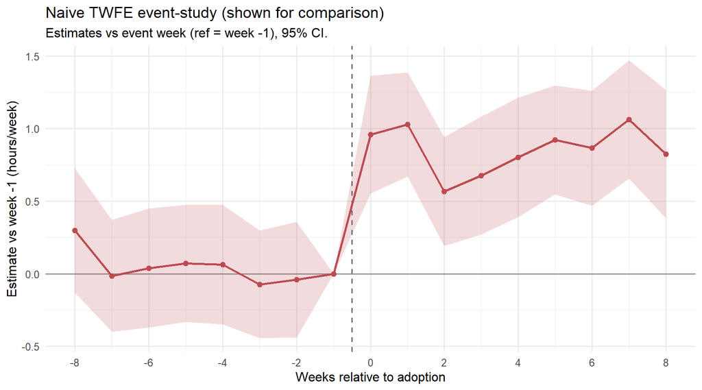

```r
es_twfe <- fixest::feols(
  Collaboration_hours ~ i(event_week, treated_grp, ref = -1) |
    PersonId + MetricDate,
  data    = panel_es,
  cluster = ~PersonId
)

tw_tab <- as.data.frame(coeftable(es_twfe))
tw_tab$term <- rownames(tw_tab)
tw_coefs <- tw_tab %>%
  filter(grepl("event_week::", term)) %>%
  mutate(
    event_week = as.integer(sub(".*event_week::(-?\\d+).*", "\\1", term)),
    lwr = Estimate - 1.96 * `Std. Error`,
    upr = Estimate + 1.96 * `Std. Error`
  )
tw_coefs <- bind_rows(
  tw_coefs,
  tibble(event_week = -1, Estimate = 0, lwr = 0, upr = 0)
) %>% arrange(event_week)

ggplot(tw_coefs, aes(event_week, Estimate)) +
  geom_hline(yintercept = 0, colour = "grey60") +
  geom_vline(xintercept = -0.5, linetype = "dashed", colour = "grey40") +
  geom_ribbon(aes(ymin = lwr, ymax = upr), fill = "#bc4b51", alpha = 0.2) +
  geom_line(linewidth = 1, colour = "#bc4b51") +
  geom_point(size = 2, colour = "#bc4b51") +
  scale_x_continuous(breaks = seq(-WINDOW, WINDOW, 2)) +
  labs(
    title    = "Naive TWFE event-study (shown for comparison)",
    subtitle = "Estimates vs event week (ref = week -1), 95% CI.",
    x = "Weeks relative to adoption", y = "Estimate vs week -1 (hours/week)"
  ) +
  theme_minimal(base_size = 12)
```

## Bonus: run the same design on a composite index

Individual metrics can be noisy. One option is to combine several related collaboration metrics into a single **z-scored composite index**, then run the same Sun and Abraham estimate on the index. Each component is standardised across the panel (mean 0, sd 1) and averaged, so no single metric’s scale dominates.

```r
components <- c("Collaboration_hours", "Chat_hours", "Emails_sent")

zscore <- function(x) (x - mean(x, na.rm = TRUE)) / sd(x, na.rm = TRUE)

panel <- panel %>%
  mutate(across(all_of(components), zscore, .names = "z_{.col}")) %>%
  mutate(collab_index = rowMeans(across(starts_with("z_")), na.rm = TRUE))

panel_es <- panel_es %>%
  left_join(select(panel, PersonId, MetricDate, collab_index),
            by = c("PersonId", "MetricDate"))

es_index <- fixest::feols(
  collab_index ~ sunab(cohort, week_num, ref.p = -1) | PersonId + Function^week_num,
  data    = panel,
  cluster = ~PersonId
)

summary(es_index, agg = "ATT")
```

```
## OLS estimation, Dep. Var.: collab_index
## Observations: 16,000
## Fixed-effects: PersonId: 400,  Function^week_num: 160
## Standard-errors: Clustered (PersonId)
##     Estimate Std. Error t value   Pr(>|t|)
## ATT  0.20026   0.039671 5.04797 6.8015e-07 ***
## ---
## Signif. codes:  0 '***' 0.001 '**' 0.01 '*' 0.05 '.' 0.1 ' ' 1
## RMSE: 0.499881     Adj. R2: 0.675023
##                  Within R2: 0.053661
```

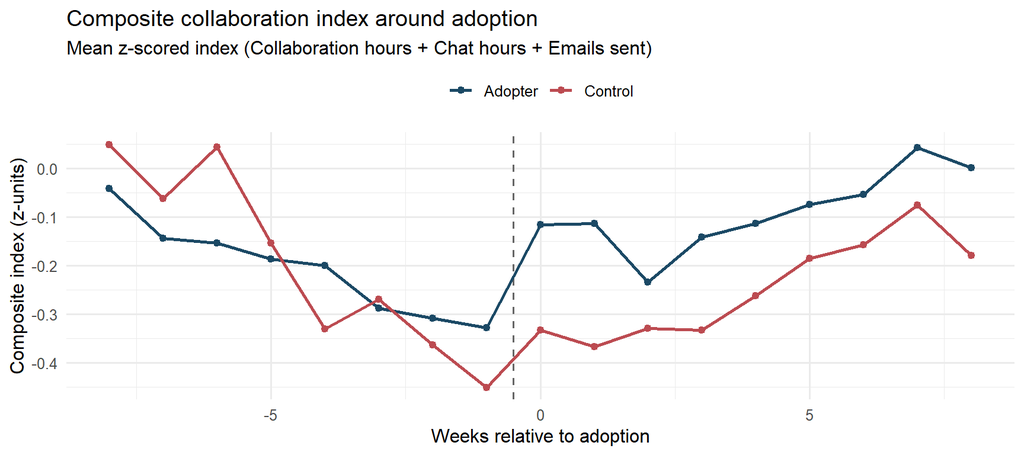

```r
# Event-time trajectory of the composite, treated vs control
idx_traj <- panel_es %>%
  mutate(grp = ifelse(treated_grp == 1, "Adopter", "Control")) %>%
  group_by(grp, event_week) %>%
  summarise(idx = mean(collab_index), .groups = "drop")

ggplot(idx_traj, aes(event_week, idx, colour = grp)) +
  geom_vline(xintercept = -0.5, linetype = "dashed", colour = "grey40") +
  geom_line(linewidth = 1) +
  geom_point(size = 1.8) +
  scale_colour_manual(values = c("Adopter" = "#1b4965", "Control" = "#bc4b51"),
                      name = NULL) +
  labs(
    title    = "Composite collaboration index around adoption",
    subtitle = "Mean z-scored index (Collaboration hours + Chat hours + Emails sent)",
    x = "Weeks relative to adoption", y = "Composite index (z-units)"
  ) +
  theme_minimal(base_size = 12) +
  theme(legend.position = "top")
```

## Wrapping up

The Sun and Abraham event-study is a portable way to ask *“did behaviour change after adoption, within the same person?”* while allowing for the fact that adopters differ from non-adopters and adopt at different times. To apply it to your own data, replace the simulation chunk with `vivainsights::import_query()`, derive the adoption week from the first non-zero Copilot action, set `TREATMENT_EFFECT` aside entirely, and let the model estimate the effect. Inspect the pre-adoption estimates, compare against the naive TWFE result, and remember that the output is an estimate under assumptions. People who adopt Copilot choose to do so, so treat any estimate as an association unless the design justifies more.